5 min read

# Using R to examine the world population datasheet

2017/07/13

# Using R to examine the world population datasheet

Corey S. Sparks

2017-07-13

These data are from the 2008 Population Reference Bureau World Population Data Sheet

```r
library(RCurl)
x <- getURL("https://raw.githubusercontent.com/coreysparks/data/master/PRB2013_new.csv")
prbdata <- read.csv(text = x)
```

Let’s have a look at some descriptive information about the data:

```r
#Frequency Table of # of Contries by Continent
table(prbdata$Continent)
```

```
##
##        Africa          Asia        Europe North America       Oceania
##            55            51            45            27            17
## South America
##            13
```

```r
#basic summary statistics for the variable TFR or the total fertility rate
summary(prbdata$TFR)
```

```
##    Min. 1st Qu.  Median    Mean 3rd Qu.    Max.
##   1.200   1.775   2.350   2.875   3.800   7.600
```

## More Descriptive statistics

```r
#just want a mean
mean(prbdata$TFR, na.rm=T)
```

```
## [1] 2.875481
```

```r
#what does R give if there's a missing case and I don't specify na.rm=T?
mean(prbdata$TFR)
```

```
## [1] 2.875481
```

```r
#standard deviation
sd(prbdata$TFR, na.rm=T)
```

```
## [1] 1.481488
```

```r
#Quantiles
quantile(prbdata$TFR, na.rm=T)
```

```
##    0%   25%   50%   75%  100%
## 1.200 1.775 2.350 3.800 7.600
```

The median is 2.35

```r
require(lattice)
```

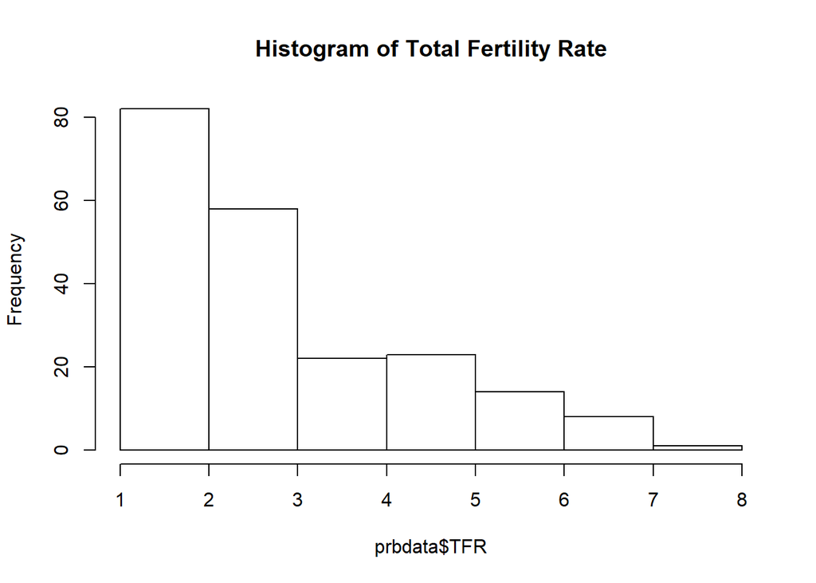

```r
#histogram of the infant mortality rate
hist(prbdata$TFR, main="Histogram of Total Fertility Rate")
```

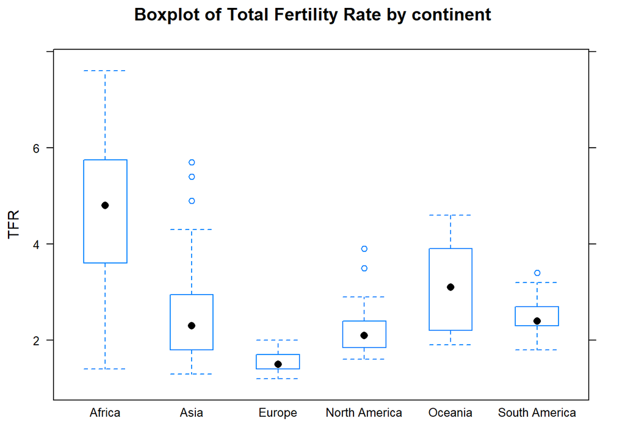

```r
#Box plot for TFR* Continent
bwplot(TFR~Continent, prbdata,main="Boxplot of Total Fertility Rate by continent")
```

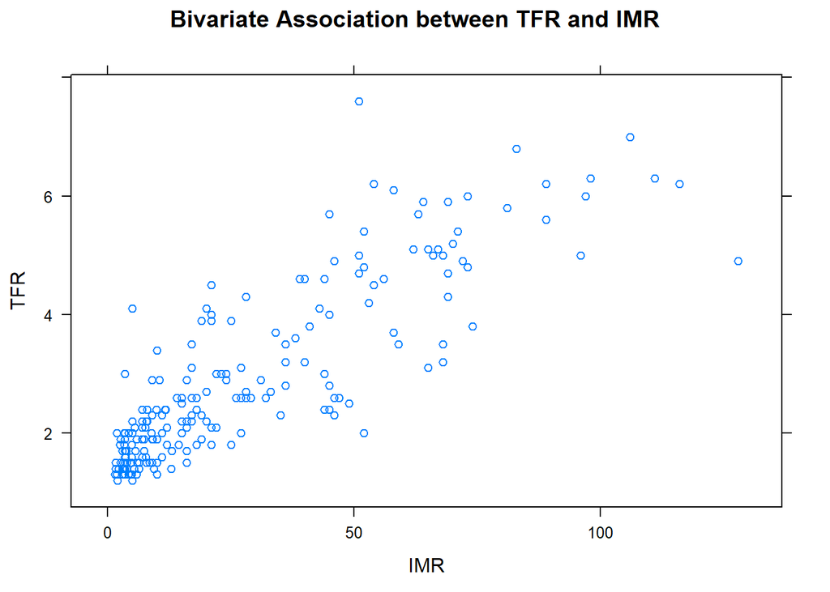

```r
#scatter plot of TFR * IMR, the infant mortality rate
xyplot(TFR~IMR, data=prbdata, main="Bivariate Association between TFR and IMR")
```

## T-tests

If our outcome is continuous and approximately normal, then we can use a t-test to compare the mean of two groups.

```r
#t-test for Africa vs Rest of the world
#Useing the I() funciton, which generates a T/F value, i.e. 2 groups, Africa or Not Africa
t.test(TFR~I(Continent=="Africa"), prbdata, var.equal=F)
```

```
##
##  Welch Two Sample t-test
##
## data:  TFR by I(Continent == "Africa")
## t = -11.559, df = 69.813, p-value < 2.2e-16
## alternative hypothesis: true difference in means is not equal to 0
## 95 percent confidence interval:
##  -2.769268 -1.954226
## sample estimates:
## mean in group FALSE  mean in group TRUE
##            2.250980            4.612727
```

### Variable summaries

Here is a summary of a factor variable, gives you the number of observations in each level of the factor

```r
summary(prbdata$Continent)
```

```
##        Africa          Asia        Europe North America       Oceania
##            55            51            45            27            17
## South America
##            13
```

```r
#summary of a numeric variable, gives you the numeric summary
summary(prbdata$Population)
```

```
##    Min. 1st Qu.  Median    Mean 3rd Qu.    Max.
##    0.01    1.10    6.60   34.26   22.65 1357.40
```

Histograms are useful for showing the “shape” of the data

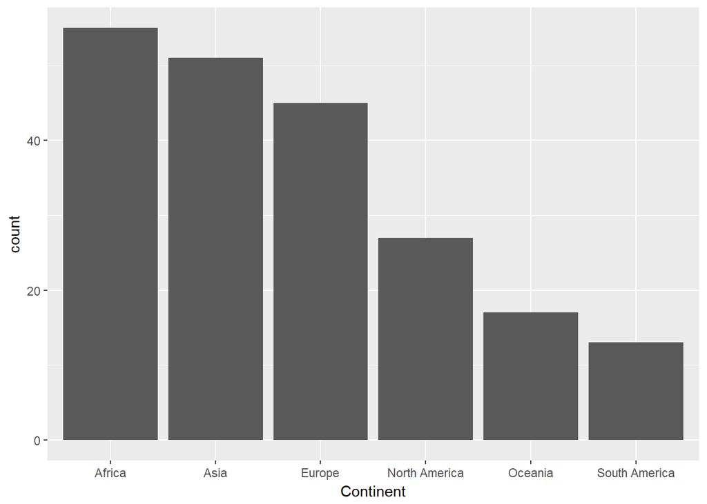

```r
library(ggplot2)
#for a factor variable, the histogram shows the % in each category
ggplot(prbdata, aes(x=Continent))+geom_bar()
```

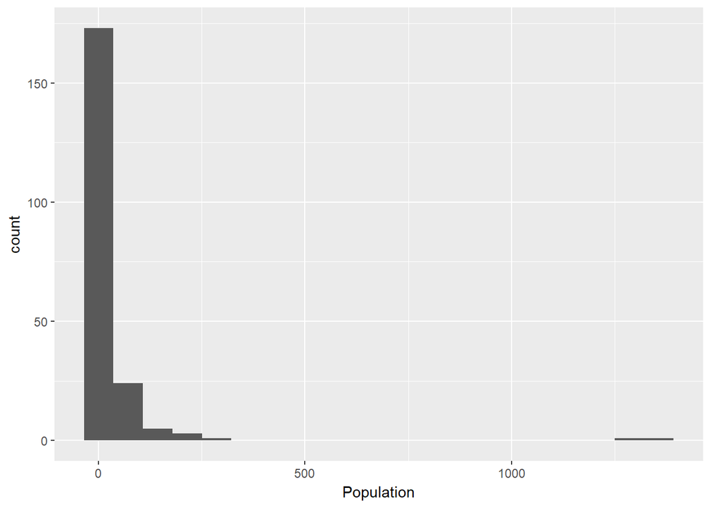

```r
#for a numeric variable, the histogram shows the % in a given bin
ggplot(prbdata, aes(x=Population))+geom_histogram(bins = 20)
```

There are many descriptive statistics, first we will calculate measures of central tendency, or scale

```r
mean(prbdata$Population)
```

```
## [1] 34.25937
```

```r
median(prbdata$Population)
```

```
## [1] 6.6
```

```r
#These two numbers are far from the same, why?

#There are two main measures of variablity, variance and the standard deviation
var(prbdata$Population)
```

```
## [1] 17831.45
```

```r
sd(prbdata$Population)
```

```
## [1] 133.5345
```

```r
#or
sqrt(var(prbdata$Population))
```

```
## [1] 133.5345
```

### Group statistics

Here we show how to make statistics by a grouping variable

```r
library(mosaic)
mean(e0Total~Continent, data=prbdata, na.rm=T)
```

```
##        Africa          Asia        Europe North America       Oceania
##      59.60000      72.60784      78.00000      75.00000      71.05882
## South America
##      73.69231
```

```r
sd(e0Total~Continent, data=prbdata, na.rm=T)
```

```
##        Africa          Asia        Europe North America       Oceania
##      8.607921      5.751794      4.035556      3.961352      6.259698
## South America
##      3.923957
```

Now we plot some variables by a group variable

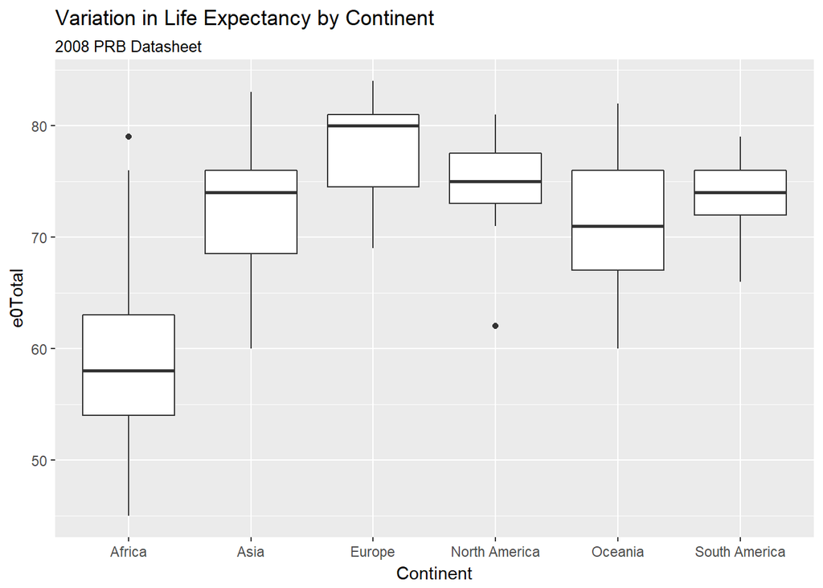

```r
#Box and Whisker plots
ggplot(prbdata, aes(x=Continent,y=e0Total))+geom_boxplot()+ggtitle(label = "Variation in Life Expectancy by Continent",subtitle = "2008 PRB Datasheet")
```

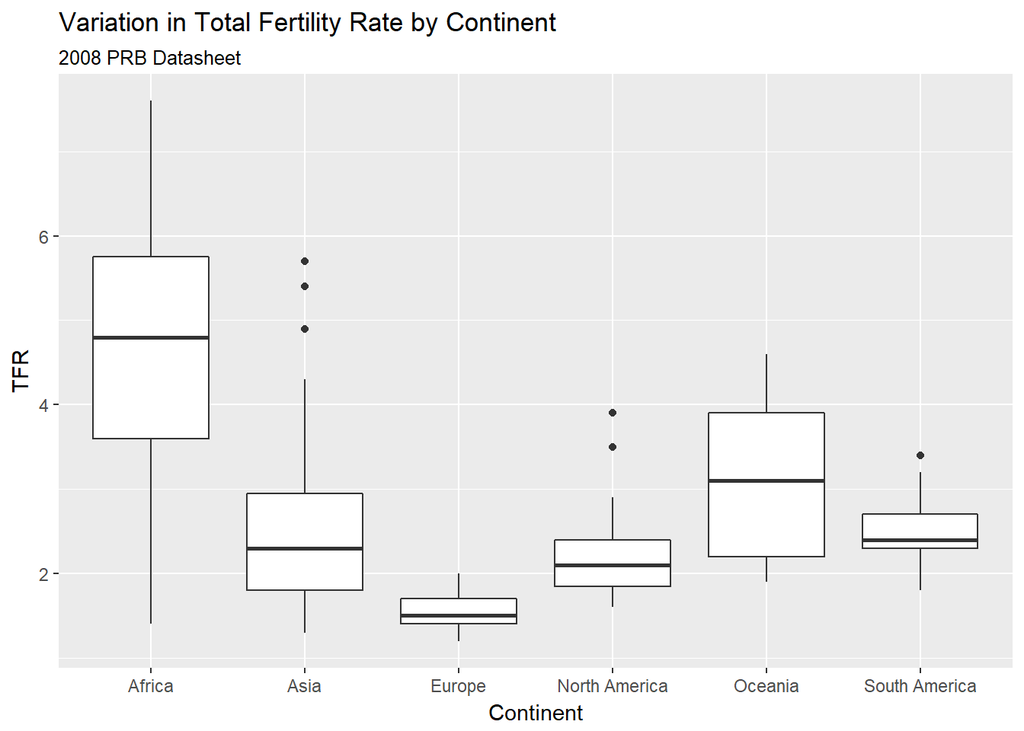

```r
ggplot(prbdata, aes(x=Continent, y=TFR))+geom_boxplot()+ggtitle(label = "Variation in Total Fertility Rate by Continent",subtitle = "2008 PRB Datasheet")
```

### Scatter plots

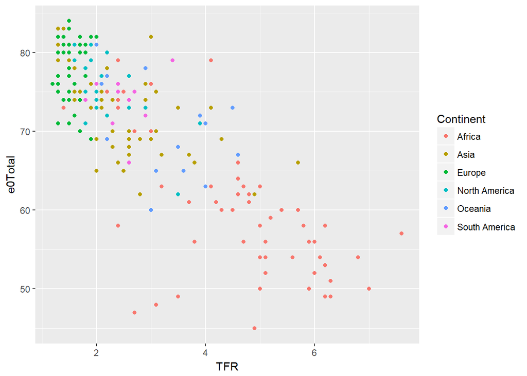

```r
ggplot(prbdata, aes(x=TFR, y=e0Total))+geom_point(aes(x=TFR, y=e0Total, colour=Continent))
```

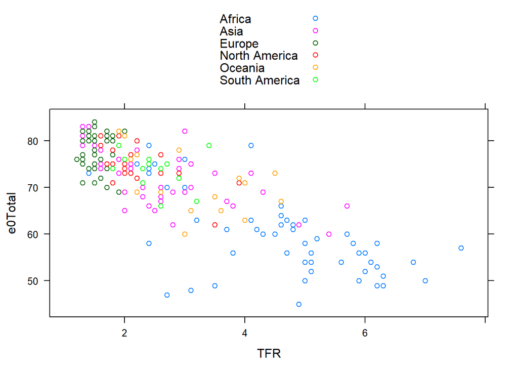

```r
#Scatter plots with group labels
xyplot(e0Total~TFR, groups=Continent,auto.key=T, data=prbdata)
```

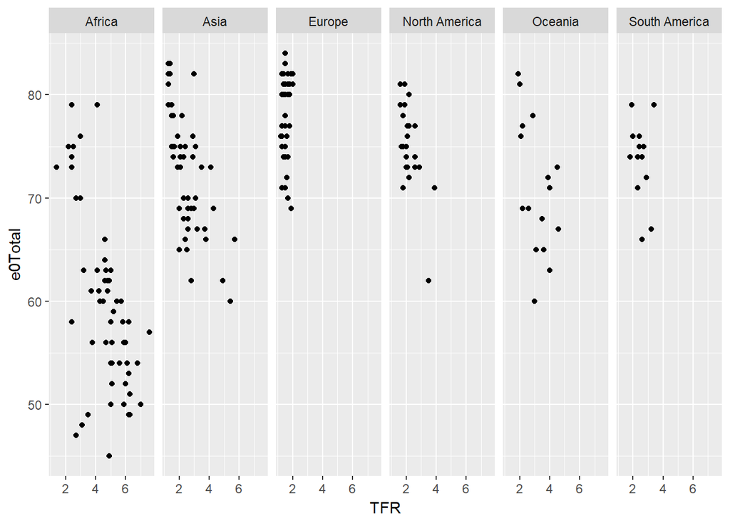

```r
#separated by a group variable
 ggplot(prbdata, aes(x=TFR, y=e0Total))+geom_point()+facet_grid(.~Continent)
```